# Exercise World Population - Fixing Errors

Ana Pereira

Fri 31 May 2019 (14:29:33)

## World Population Data

We will use a subset of the United Nations world population data[^1]. The subset has 5 yearly population estimates from 1950 until 2015 by age groups for both males and females. The variables in the dataset are as follows.

- `continent`: Continent
- `Location`: Country name
- `Time`: Year
- `AgeGrp`: Age group (e.g. 15-19, 20-14)
- `AgeGrpStart`: initial age of the age group
- `PopMale`: Total male population (thousands)
- `PopFemale`: Total female population (thousands)

## Exercise Questions

We want to answer the following questions with data:

1. How is the total population changing by continent over time?
2. What are the time trends for male/female proportions by continent?

## Read in the data

We start by reading the data from file `World-Population.csv` into object called `wpOrig`.

```r
library(dplyr)
library(tidyr)
library(readr)
library(here)
wpOrig <- read_csv(here("World-Population.csv"))
glimpse(wpOrig)
```

```
## Observations: 47,946
## Variables: 7
## $ continent   <chr> "Asia", "Asia", "Asia", "Asia", "Asia", "Asia", "A...
## $ Location    <chr> "Afghanistan", "Afghanistan", "Afghanistan", "Afgh...
## $ Time        <dbl> 1950, 1950, 1950, 1950, 1950, 1950, 1950, 1950, 19...
## $ AgeGrp      <chr> "0-4", "5-9", "10-14", "15-19", "20-24", "25-29", ...
## $ AgeGrpStart <dbl> 0, 5, 10, 15, 20, 25, 30, 35, 40, 45, 50, 55, 60, ...
## $ PopFemale   <dbl> 661.578, 487.335, 423.326, 369.363, 318.392, 272.2...
## $ PopMale     <dbl> 630.044, 516.206, 461.378, 414.369, 374.109, 321.3...
```

### Pre-processing the Data

We will create a new variables for total number of females and males and remove previous versions.

```r
wp <- wpOrig %>%
  rename(Continent=continent, Country=Location, Year=Time) %>%
  mutate(PopF = 1000*PopFemale,PopM = 1000*PopMale,PopT = PopF + PopM) %>%
  select(-PopFemale, -PopMale) %>%
  arrange(Continent, Country, Year, AgeGrpStart)

glimpse(wp)
```

```
## Observations: 47,946
## Variables: 8
## $ Continent   <chr> "Africa", "Africa", "Africa", "Africa", "Africa", ...
## $ Country     <chr> "Algeria", "Algeria", "Algeria", "Algeria", "Alger...
## $ Year        <dbl> 1950, 1950, 1950, 1950, 1950, 1950, 1950, 1950, 19...
## $ AgeGrp      <chr> "0-4", "5-9", "10-14", "15-19", "20-24", "25-29", ...
## $ AgeGrpStart <dbl> 0, 5, 10, 15, 20, 25, 30, 35, 40, 45, 50, 55, 60, ...
## $ PopF        <dbl> 688027, 571364, 518022, 453872, 385816, 302698, 28...
## $ PopM        <dbl> 715107, 580296, 529938, 488349, 396394, 317326, 28...
## $ PopT        <dbl> 1403134, 1151660, 1047960, 942221, 782210, 620024,...
```

## Population Change by Continent

> How is the total population changing by continent over time?

We will calculate the total populations for each continent by year. We will also add a world total

```r
ctt <- wp %>%
  # Add total for the world
  mutate(Continent = "World") %>%
  rbind(wp) %>%
  group_by(Continent, Year) %>%
  summarise(TotF = sum(PopF), TotM = sum(PopM), Total = sum(PopT)) %>%
  arrange(Continent, Year)
glimpse(ctt)
```

```
## Observations: 84
## Variables: 5
## Groups: Continent [6]
## $ Continent <chr> "Africa", "Africa", "Africa", "Africa", "Africa", "A...
## $ Year      <dbl> 1950, 1955, 1960, 1965, 1970, 1975, 1980, 1985, 1990...
## $ TotF      <dbl> 114938993, 127658920, 143230943, 161921049, 18382964...
## $ TotM      <dbl> 113449031, 125999415, 141513814, 160072688, 18204850...
## $ Total     <dbl> 228388024, 253658335, 284744757, 321993737, 36587814...
```

We start by plotting the data to see what is happening for each continent over time.

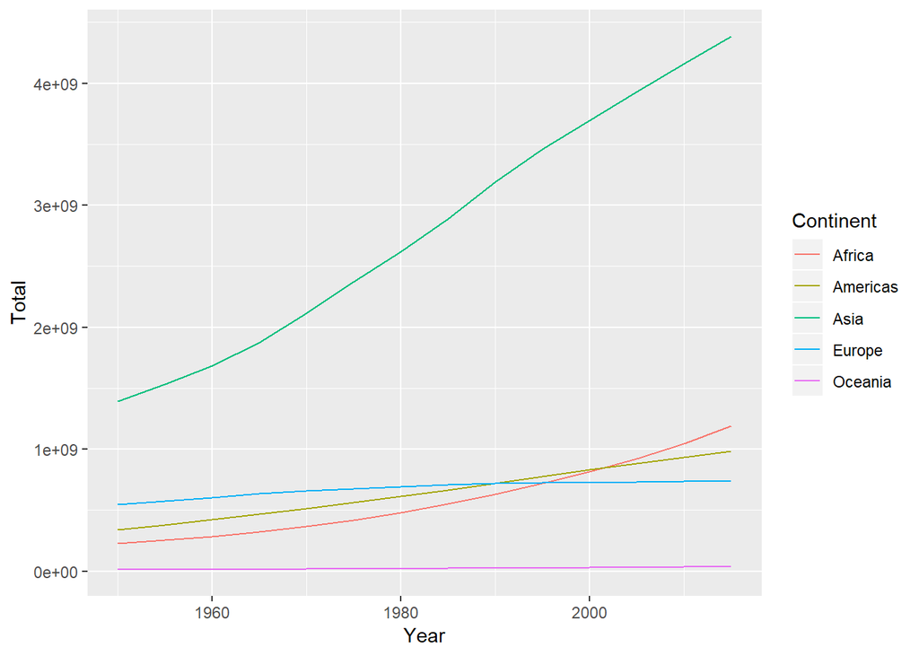

```r
library(ggplot2)
ctt %>%
  filter(Continent != "World") %>%
  ggplot(aes(Year, Total, colour=Continent)) +  geom_line()
```

Let’s look at the actual numbers in a “pretty” table.

```r
ctwide <-  ctt %>% select(Continent, Year, Total) %>% spread(Continent, Total)

# Use the kable from the knitr package
library(knitr)
ctwide %>%  kable()
```

| Year | Africa | Americas | Asia | Europe | Oceania | World |
| --- | --- | --- | --- | --- | --- | --- |
| 1950 | 228388024 | 338469328 | 1393335794 | 549110350 | 12380254 | 2521683750 |
| 1955 | 253658335 | 377643370 | 1533453741 | 576838680 | 13887960 | 2755482086 |
| 1960 | 284744757 | 422453468 | 1685458729 | 605640887 | 15503927 | 3013801768 |
| 1965 | 321993737 | 469257663 | 1873695164 | 635025411 | 17201316 | 3317173291 |
| 1970 | 365878147 | 515270994 | 2117891232 | 657017069 | 19295236 | 3675352678 |
| 1975 | 417287674 | 563502213 | 2372306276 | 677248157 | 21019951 | 4051364271 |
| 1980 | 479291597 | 614169310 | 2618108828 | 693831033 | 22462579 | 4427863347 |
| 1985 | 551977451 | 667078179 | 2889443637 | 707830364 | 24308767 | 4840638398 |
| 1990 | 633638928 | 721223752 | 3192803774 | 721275224 | 26366511 | 5295308189 |
| 1995 | 721864303 | 776673306 | 3458934257 | 727642257 | 28400427 | 5713514550 |
| 2000 | 816359720 | 833148649 | 3698215799 | 726742271 | 30370488 | 6104836927 |
| 2005 | 923346192 | 883645539 | 3930853340 | 729801428 | 32669538 | 6500316037 |
| 2010 | 1047922697 | 934907399 | 4159693812 | 736652770 | 35719033 | 6914895711 |
| 2015 | 1192736248 | 982775869 | 4383902319 | 740296333 | 38595075 | 7338305844 |

There is a lot to absorb in the previous table. Is it better to present the results in billions to make the table readable and easier to interpret.

```r
ctwideB <-  ctt %>%
  mutate(TotalB = paste(format(round(Total/1e9, 2), trim = TRUE), "B")) %>%
  select(Continent, Year, TotalB) %>%
  spread(Continent, TotalB)

ctwideB %>%  kable()
```

| Year | Africa | Americas | Asia | Europe | Oceania | World |
| --- | --- | --- | --- | --- | --- | --- |
| 1950 | 0.23 B | 0.34 B | 1.39 B | 0.55 B | 0.01 B | 2.52 B |
| 1955 | 0.25 B | 0.38 B | 1.53 B | 0.58 B | 0.01 B | 2.76 B |
| 1960 | 0.28 B | 0.42 B | 1.69 B | 0.61 B | 0.02 B | 3.01 B |
| 1965 | 0.32 B | 0.47 B | 1.87 B | 0.64 B | 0.02 B | 3.32 B |
| 1970 | 0.37 B | 0.52 B | 2.12 B | 0.66 B | 0.02 B | 3.68 B |
| 1975 | 0.42 B | 0.56 B | 2.37 B | 0.68 B | 0.02 B | 4.05 B |
| 1980 | 0.48 B | 0.61 B | 2.62 B | 0.69 B | 0.02 B | 4.43 B |
| 1985 | 0.55 B | 0.67 B | 2.89 B | 0.71 B | 0.02 B | 4.84 B |
| 1990 | 0.63 B | 0.72 B | 3.19 B | 0.72 B | 0.03 B | 5.30 B |
| 1995 | 0.72 B | 0.78 B | 3.46 B | 0.73 B | 0.03 B | 5.71 B |
| 2000 | 0.82 B | 0.83 B | 3.70 B | 0.73 B | 0.03 B | 6.10 B |
| 2005 | 0.92 B | 0.88 B | 3.93 B | 0.73 B | 0.03 B | 6.50 B |
| 2010 | 1.05 B | 0.93 B | 4.16 B | 0.74 B | 0.04 B | 6.91 B |
| 2015 | 1.19 B | 0.98 B | 4.38 B | 0.74 B | 0.04 B | 7.34 B |

### Questions

1. Which continent had the highest percentage growth overall years?
2. Which continent had the lowest percentage growth overall years?

## Proportion Trends by Continent

> What are the time trends for male/female proportions by continent?

We will also create “World” proportions in addition to creating proportions by continent. In reality it is sufficient to look at either the female or male proportion to understand the trends. We will look a the female proportions.

```r
ctprop <- ctt %>%
  mutate(PropF = TotF/Total, PropM = TotM/Total)
```

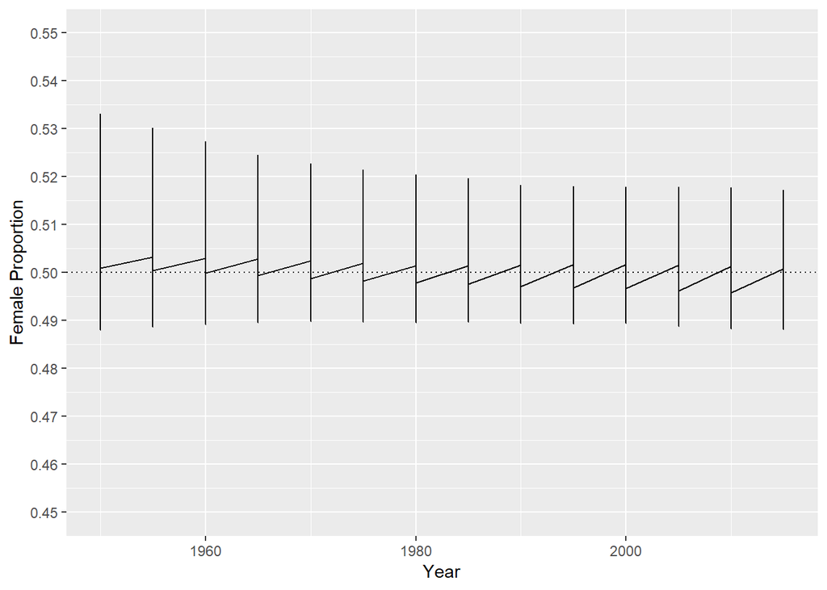

```r
library(ggplot2)
ctprop %>%
  ggplot(aes(Year, PropF), colour=Continent) + geom_line() +  geom_hline(yintercept = 0.5, lty=3) + scale_y_continuous(limits = c(.45, .55), breaks = seq(0.45, .55, 0.01)) +  ylab("Female Proportion")
```

Let’s look at the female proportions (percentages) in a table.

```r
ctwidePct <-  ctprop %>%
  mutate(PctF = paste0(format(round(100*PropF, 1), trim = TRUE), "%")) %>%
  select(Continent, Year, PctF) %>%
  spread(Continent, PctF)

ctwidePct %>%  kable()
```

| Year | Africa | Americas | Asia | Europe | Oceania | World |
| --- | --- | --- | --- | --- | --- | --- |
| 1950 | 50.3% | 50.0% | 48.8% | 53.3% | 49.2% | 50.1% |
| 1955 | 50.3% | 50.1% | 48.9% | 53.0% | 49.2% | 50.0% |
| 1960 | 50.3% | 50.2% | 48.9% | 52.7% | 49.3% | 50.0% |
| 1965 | 50.3% | 50.2% | 48.9% | 52.5% | 49.5% | 49.9% |
| 1970 | 50.2% | 50.3% | 49.0% | 52.3% | 49.6% | 49.9% |
| 1975 | 50.2% | 50.4% | 49.0% | 52.1% | 49.7% | 49.8% |
| 1980 | 50.1% | 50.5% | 49.0% | 52.0% | 49.9% | 49.8% |
| 1985 | 50.2% | 50.5% | 49.0% | 52.0% | 49.9% | 49.8% |
| 1990 | 50.2% | 50.6% | 48.9% | 51.8% | 50.0% | 49.7% |
| 1995 | 50.2% | 50.6% | 48.9% | 51.8% | 50.0% | 49.7% |
| 2000 | 50.2% | 50.5% | 48.9% | 51.8% | 50.0% | 49.7% |
| 2005 | 50.2% | 50.5% | 48.9% | 51.8% | 50.0% | 49.6% |
| 2010 | 50.1% | 50.5% | 48.8% | 51.8% | 49.9% | 49.6% |
| 2015 | 50.1% | 50.5% | 48.8% | 51.7% | 50.0% | 49.6% |

[^1]: Source: https://population.un.org/wpp/Download/Standard/CSV/ Dataset: "WPP2017_PopulationByAgeSex_Medium.csv